# Data Analysis: & Decision Making - Presentation Report

Akshat Shreemali, Darshan Dalvi, Prashant Kasalkar, Vaibhav Bavishi

**Objective**

Predicting the number of Library Subscriptions for journals

```r
# required libraries
library(AER)
```

```r
library(ggplot2)
library(GGally)
library(faraway)
library(scatterplot3d)
library(gridExtra)
```

**INTRODUCTION**

Data is on Subscriptions to economic journals at US libraries for the year 2000. Data set is in R package ‘AER’ under the name ‘Journals’. Data contains total 10 variables with 180 observations. The variables are: 1. title <- Character variable containing the Journal titles 2. publisher <- A factor variable containing the publisher names 3. society <- A factor indicating whether the journal belongs to a scholar society or not 4. price <- Numeric value containg the Library Subscription price of the Journals 5. pages <- Numeric value containg the number of pages in the Journal 6. charpp <- Numeric value containg the number of characters per page 7. citations <- total number of citations 8. foundingyear <- the year when the Journal was founded 9. subs <- the number of library subscriptions 10. field <- A factor containing the field description

**Structure of the data**

```r
data("Journals") # loading Journals data into R
str(Journals)
```

```
## 'data.frame':    180 obs. of  10 variables:
##  $ title       : chr  "Asian-Pacific Economic Literature" "South African Journal of Economic History" "Computational Economics" "MOCT-MOST Economic Policy in Transitional Economics" ...
##  $ publisher   : Factor w/ 52 levels "ANU Press","Academic Press",..: 11 45 28 28 18 18 13 18 28 11 ...
##  $ society     : Factor w/ 2 levels "no","yes": 1 1 1 1 1 1 1 1 1 1 ...
##  $ price       : int  123 20 443 276 295 344 90 242 226 262 ...
##  $ pages       : int  440 309 567 520 791 609 602 665 243 386 ...
##  $ charpp      : int  3822 1782 2924 3234 3024 2967 3185 2688 3010 2501 ...
##  $ citations   : int  21 22 22 22 24 24 24 27 28 30 ...
##  $ foundingyear: int  1986 1986 1987 1991 1972 1994 1995 1968 1987 1949 ...
##  $ subs        : int  14 59 17 2 96 15 14 202 46 46 ...
##  $ field       : Factor w/ 24 levels "General","Economic History",..: 1 2 3 4 5 6 7 3 4 1 ...
```

```r
summary (Journals)
```

```
##     title                           publisher  society       price
##  Length:180         Elsevier             :42   no :164   Min.   :  20.0
##  Class :character   Blackwell            :26   yes: 16   1st Qu.: 134.5
##  Mode  :character   Kluwer               :16             Median : 282.0
##                     Springer             :10             Mean   : 417.7
##                     Academic Press       : 9             3rd Qu.: 540.8
##                     Univ of Chicago Press: 7             Max.   :2120.0
##                     (Other)              :70
##      pages            charpp       citations        foundingyear
##  Min.   : 167.0   Min.   :1782   Min.   :  21.00   Min.   :1844
##  1st Qu.: 548.8   1st Qu.:2715   1st Qu.:  97.75   1st Qu.:1963
##  Median : 693.0   Median :3010   Median : 262.50   Median :1973
##  Mean   : 827.7   Mean   :3233   Mean   : 647.06   Mean   :1967
##  3rd Qu.: 974.2   3rd Qu.:3477   3rd Qu.: 656.00   3rd Qu.:1982
##  Max.   :2632.0   Max.   :6859   Max.   :8999.00   Max.   :1996
##
##       subs                       field
##  Min.   :   2.0   General           :40
##  1st Qu.:  52.0   Specialized       :14
##  Median : 122.5   Public Finance    :12
##  Mean   : 196.9   Development       :11
##  3rd Qu.: 268.2   Finance           :11
##  Max.   :1098.0   Urban and Regional: 8
##                   (Other)           :84
```

Based on summary of the data, following activities can be done

1. No data cleaning is required since there are no missing values

**Graphical Representation of Distribution ‘Subs’ Variable**

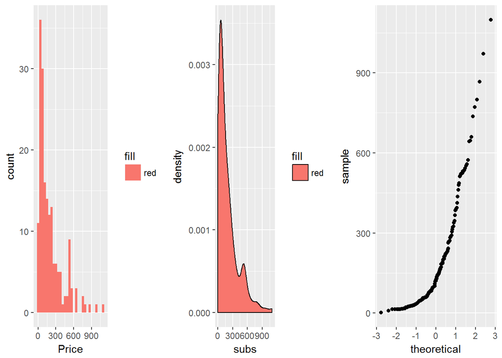

```r
plot1 = qplot(subs, data = Journals, fill = "red", xlab = "Price")
plot2 = qplot(subs, data = Journals, geom = "density", fill = "red")
plot3 = qplot(sample = subs, data = Journals)
grid.arrange(plot1, plot2, plot3, ncol = 3)
```

Result:

**Overlay Plot**

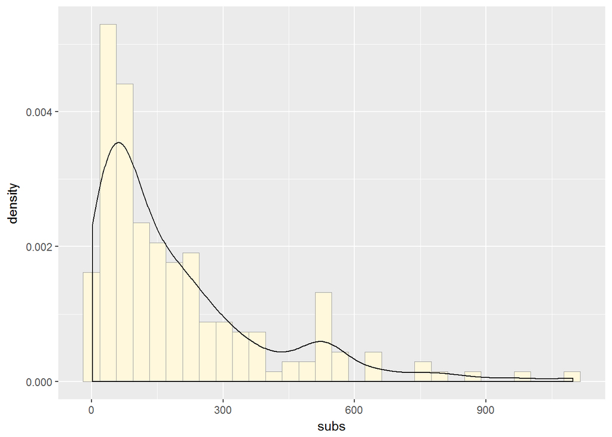

```r
ggplot(Journals, aes(x = subs, y =..density..)) + geom_histogram( fill = "cornsilk", colour =" grey60", size =.2) + geom_density()
```

**BoxPlot**

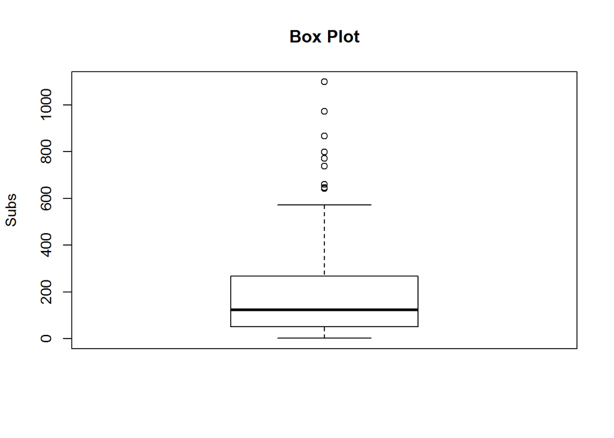

```r
boxplot(Journals$subs, ylab = "Subs", main = "Box Plot")
```

**Boxplot between subs and society**

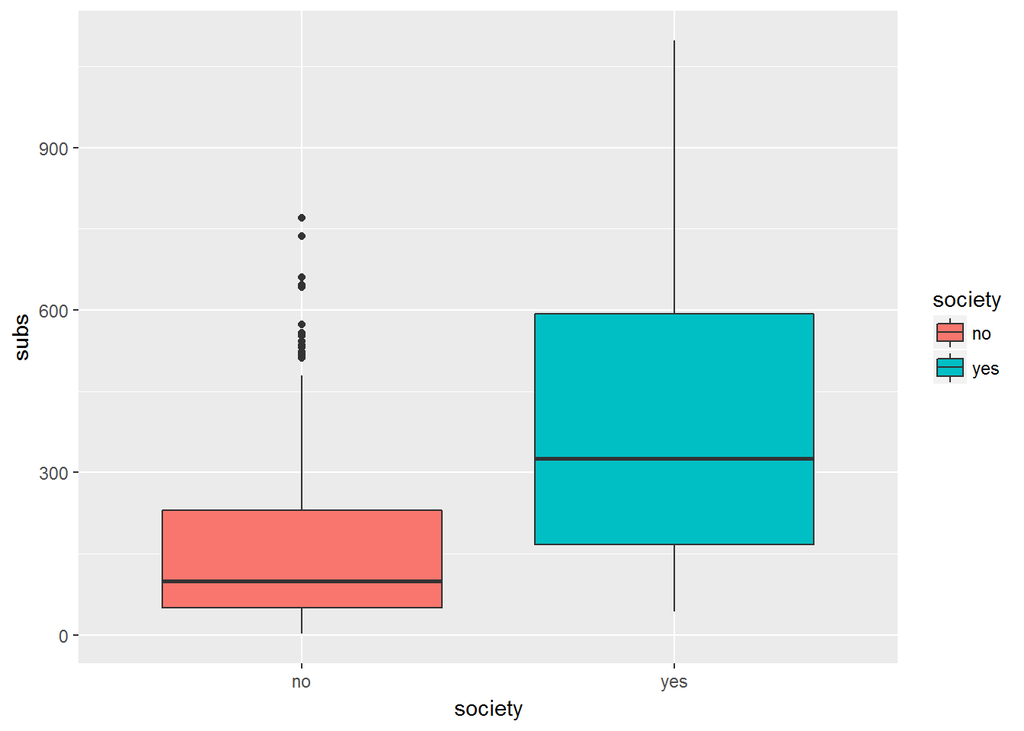

```r
ggplot(aes(society, subs), data = Journals) + geom_boxplot(aes(fill = society))
```

Analysis: We can clearly see that if the Journals is published by the scholarly society then the number of subs increases

**Scatterplot of Price vs subs**

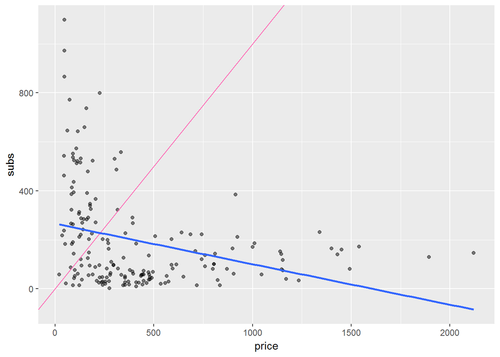

```r
#plot(Journals$price,Journals$subs)

 (qplot(price, subs, data = Journals,alpha=I(1/2),shape=I(19)) +
  geom_abline(intercept = 0,
              slope = 1,
              color="hot pink") +
  geom_smooth(method = "lm", se=FALSE))
```

We can see it clearly that the relationship between price and subs is non linear

**Identifying corelations between variables (only numeric variables)**

```r
journal_numeric<- Journals[,c("price","subs","charpp","pages")]

cor(journal_numeric)
```

```
##              price        subs       charpp        pages
## price   1.00000000 -0.31196769  0.074579257  0.493724318
## subs   -0.31196769  1.00000000  0.083192651  0.371405508
## charpp  0.07457926  0.08319265  1.000000000 -0.008986512
## pages   0.49372432  0.37140551 -0.008986512  1.000000000
```

**Performing Step wise Regression on our model** Using step wise we can identify those predictors which are not required

```r
g<-lm(subs~.-field-title-publisher,data=Journals) # removing character variables
g1<-step(g)
```

```
## Start:  AIC=1780.96
## subs ~ (title + publisher + society + price + pages + charpp +
##     citations + foundingyear + field) - field - title - publisher
##
##                Df Sum of Sq     RSS    AIC
## - society       1       230 3300057 1779.0
## <none>                      3299828 1781.0
## - foundingyear  1     41599 3341427 1781.2
## - charpp        1     63275 3363103 1782.4
## - citations     1    414434 3714262 1800.2
## - pages         1    636096 3935924 1810.7
## - price         1   1122475 4422303 1831.7
##
## Step:  AIC=1778.97
## subs ~ price + pages + charpp + citations + foundingyear
##
##                Df Sum of Sq     RSS    AIC
## <none>                      3300057 1779.0
## - foundingyear  1     41371 3341428 1779.2
## - charpp        1     67108 3367165 1780.6
## - citations     1    425311 3725369 1798.8
## - pages         1    709989 4010046 1812.0
## - price         1   1269262 4569319 1835.5
```

```r
g<-lm(subs~.-field-title-publisher,data=Journals)
summary(g)
```

```
##
## Call:
## lm(formula = subs ~ . - field - title - publisher, data = Journals)
##
## Residuals:
##     Min      1Q  Median      3Q     Max
## -473.18  -81.60  -31.83   69.58  505.38
##
## Coefficients:
##                Estimate Std. Error t value Pr(>|t|)
## (Intercept)  1360.89705  904.70271   1.504   0.1343
## societyyes      4.57756   41.71326   0.110   0.9127
## price          -0.27930    0.03641  -7.671 1.19e-12 ***
## pages           0.21010    0.03638   5.775 3.50e-08 ***
## charpp          0.02383    0.01308   1.821   0.0703 .
## citations       0.05425    0.01164   4.661 6.25e-06 ***
## foundingyear   -0.67812    0.45919  -1.477   0.1415
## ---
## Signif. codes:  0 '***' 0.001 '**' 0.01 '*' 0.05 '.' 0.1 ' ' 1
##
## Residual standard error: 138.1 on 173 degrees of freedom
## Multiple R-squared:  0.5593, Adjusted R-squared:  0.544
## F-statistic: 36.59 on 6 and 173 DF,  p-value: < 2.2e-16
```

**Checking NULL HYPOTHESIS**

As we can see Since the F-Statistic is 36.59 , we can reject the NULL Hypothesis and can accept the Alternate Hypothesis

Theirfore we can proceed with our model and can normalize and improve it

**Fit Plot and Residual Plot** Fit plot for the variable ‘subs’

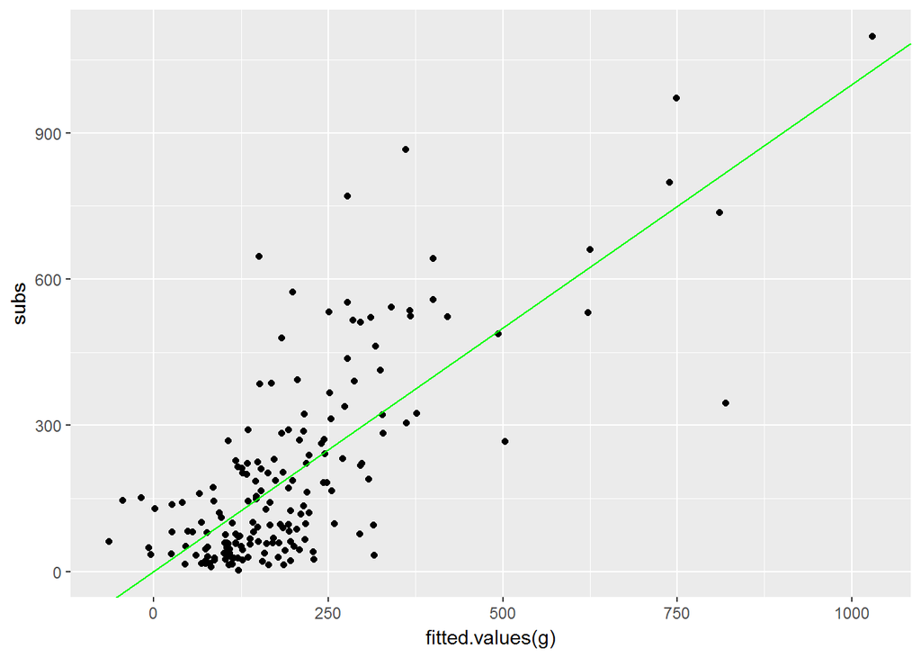

```r
qplot(fitted.values(g), subs, data = Journals) + geom_abline(intercept = 0, slope = 1, color = "green")
```

Analysis: 1. We don’t observe any pattern and the distribution is widely spread with some outliers

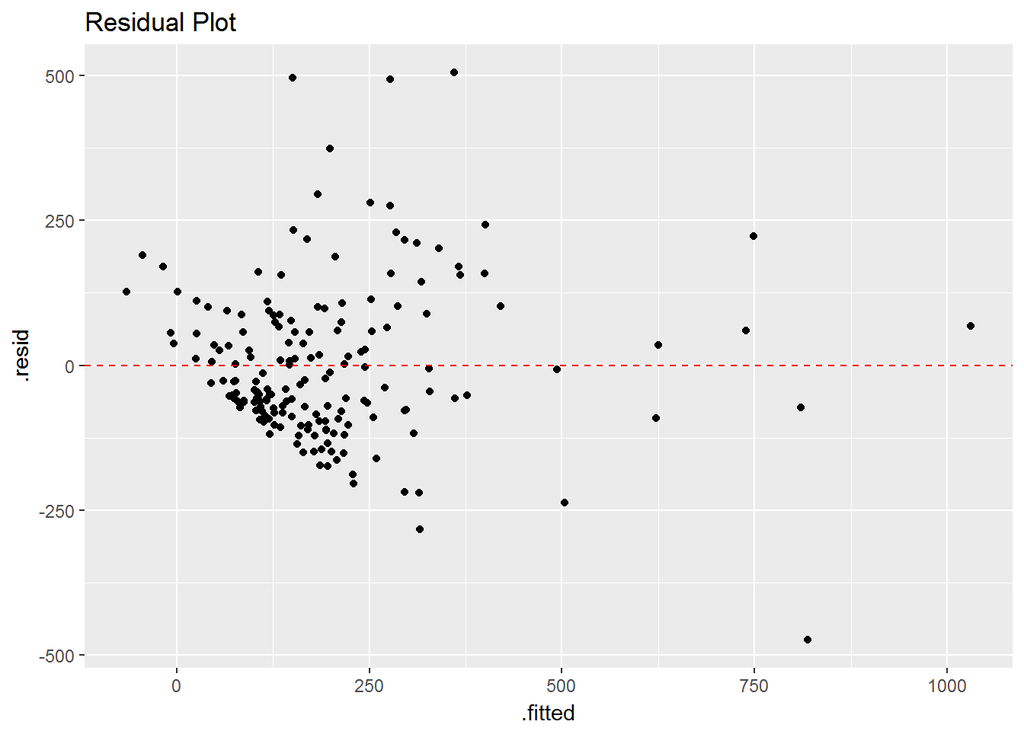

```r
ggplot(g, aes(.fitted, .resid)) + geom_point() + geom_hline(yintercept = 0, color = "red", linetype = "dashed") + ggtitle("Residual Plot")
```

Analysis:

The points in a residual plot are randomly dispersed around the horizontal axis, a linear regression model is appropriate for the data.

Exploring Model Structure

```r
cor(g$resid, Journals$subs)
```

```
## [1] 0.6638417
```

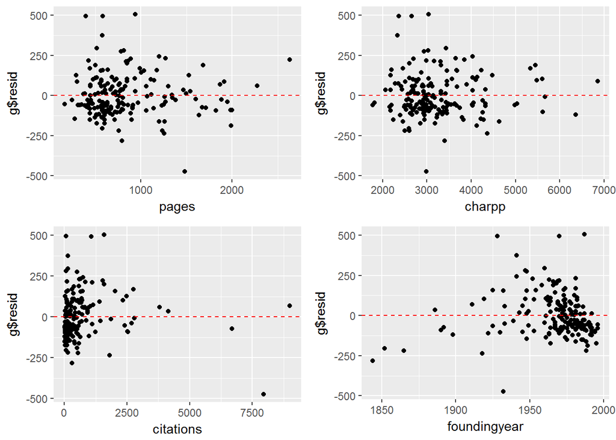

```r
plot1 = qplot(pages, g$resid, data = Journals) +
  geom_hline(yintercept = 0, color = "red", linetype = "dashed")
plot2 = qplot(charpp, g$resid, data = Journals) +
  geom_hline(yintercept = 0, color = "red", linetype = "dashed")
plot3 = qplot(citations, g$resid, data = Journals) +
  geom_hline(yintercept = 0, color = "red", linetype = "dashed")
plot4 = qplot(foundingyear, g$resid, data = Journals) +
  geom_hline(yintercept = 0, color = "red", linetype = "dashed")
grid.arrange(plot1,plot2,plot3,plot4,nrow=2,ncol=2)
```

Analysis:

Normality of the Residual

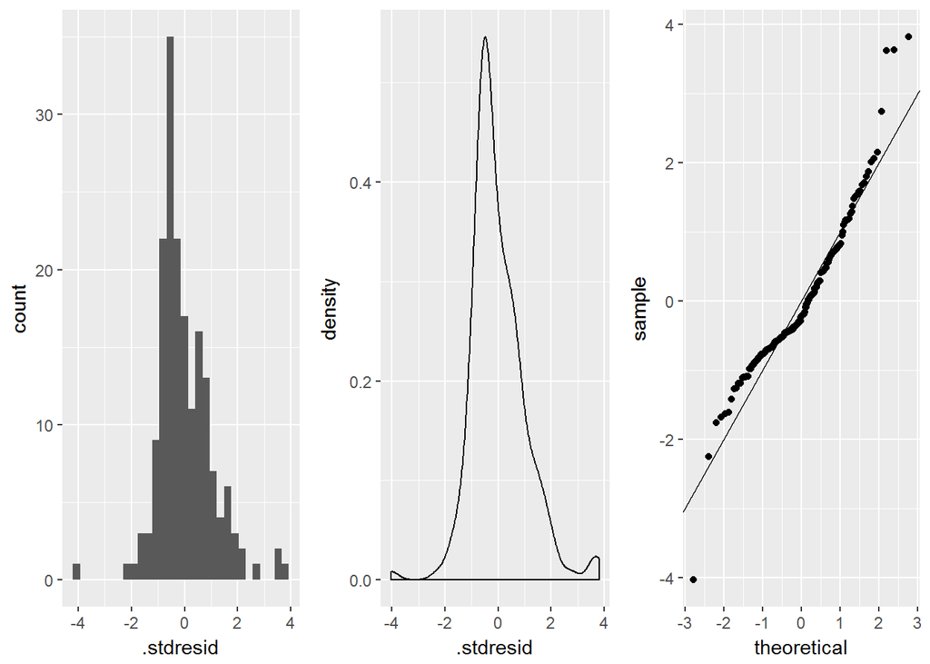

```r
mod = fortify(g)
plot1 = qplot(.stdresid, data = mod, geom = "histogram")
plot2 = qplot(.stdresid, data = mod, geom = "density")
plot3 = qplot(sample = .stdresid, data = mod, geom = "qq") +geom_abline()
grid.arrange(plot1, plot2, plot3, nrow = 1)
```

Analysis : The residual do not look as though they come from a normal distribution. The QQ-Plot looks slightly linear with outliers Density plot is not appearing like a normal distribution

**Creating another model to improve efficiency of the model**

```r
journals <- Journals[, c("subs", "price")]
journals$citeprice <- Journals$price/Journals$citations
journals$age <- 2000 - Journals$foundingyear
journals$chars <- Journals$charpp*Journals$pages/10^6
summary(journals)
```

```
##       subs            price          citeprice              age
##  Min.   :   2.0   Min.   :  20.0   Min.   : 0.005223   Min.   :  4.00
##  1st Qu.:  52.0   1st Qu.: 134.5   1st Qu.: 0.464495   1st Qu.: 17.75
##  Median : 122.5   Median : 282.0   Median : 1.320513   Median : 27.00
##  Mean   : 196.9   Mean   : 417.7   Mean   : 2.548455   Mean   : 33.09
##  3rd Qu.: 268.2   3rd Qu.: 540.8   3rd Qu.: 3.440171   3rd Qu.: 37.25
##  Max.   :1098.0   Max.   :2120.0   Max.   :24.459459   Max.   :156.00
##      chars
##  Min.   : 0.5506
##  1st Qu.: 1.6577
##  Median : 2.1877
##  Mean   : 2.6727
##  3rd Qu.: 3.1829
##  Max.   :10.1279
```

**Creating another model with log for our data on Numeric predictors**

```r
g3 <- lm(subs ~ citeprice + age + chars, data = log(journals))
summary(g3)
```

```
##
## Call:
## lm(formula = subs ~ citeprice + age + chars, data = log(journals))
##
## Residuals:
##      Min       1Q   Median       3Q      Max
## -2.51996 -0.41211  0.03173  0.44657  1.80588
##
## Coefficients:
##             Estimate Std. Error t value Pr(>|t|)
## (Intercept)  3.20665    0.31412  10.208  < 2e-16 ***
## citeprice   -0.40772    0.04196  -9.717  < 2e-16 ***
## age          0.42365    0.08972   4.722 4.75e-06 ***
## chars        0.20561    0.10747   1.913   0.0573 .
## ---
## Signif. codes:  0 '***' 0.001 '**' 0.01 '*' 0.05 '.' 0.1 ' ' 1
##
## Residual standard error: 0.7047 on 176 degrees of freedom
## Multiple R-squared:  0.6132, Adjusted R-squared:  0.6066
## F-statistic: 93.01 on 3 and 176 DF,  p-value: < 2.2e-16
```

Performing Shapiro test for our model

```r
shapiro.test(residuals(g3))
```

```
##
##  Shapiro-Wilk normality test
##
## data:  residuals(g3)
## W = 0.98325, p-value = 0.02958
```

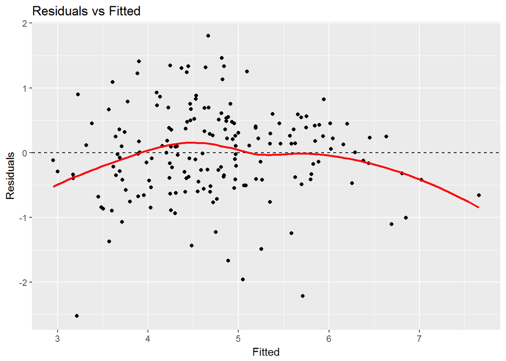

```r
mod2 <- fortify(g3)
p2 <- qplot(.fitted, .resid, data = mod2) + geom_hline(yintercept = 0, linetype = "dashed") +
  labs(title = "Residuals vs Fitted", x = "Fitted", y = "Residuals") + geom_smooth(color = "red",  se = F)
p2
```

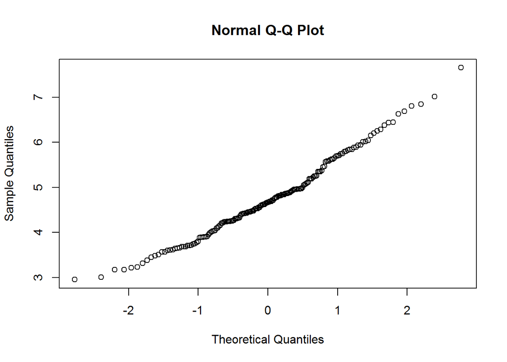

```r
qqnorm(fitted.values(g3))
```

**Creating another model with quadratic perdictors**

```r
g4 <- lm(subs ~ citeprice + I(citeprice^2) + I(citeprice^3) +
           age + I(age * citeprice) + chars, data = log(journals))
summary(g4)
```

```
##
## Call:
## lm(formula = subs ~ citeprice + I(citeprice^2) + I(citeprice^3) +
##     age + I(age * citeprice) + chars, data = log(journals))
##
## Residuals:
##      Min       1Q   Median       3Q      Max
## -2.25623 -0.41477  0.07605  0.40056  1.77711
##
## Coefficients:
##                     Estimate Std. Error t value Pr(>|t|)
## (Intercept)         3.407596   0.318414  10.702  < 2e-16 ***
## citeprice          -0.960936   0.189220  -5.078 9.78e-07 ***
## I(citeprice^2)      0.016510   0.024135   0.684  0.49484
## I(citeprice^3)      0.003667   0.006862   0.534  0.59380
## age                 0.373054   0.089361   4.175 4.72e-05 ***
## I(age * citeprice)  0.155777   0.055050   2.830  0.00521 **
## chars               0.234618   0.106133   2.211  0.02838 *
## ---
## Signif. codes:  0 '***' 0.001 '**' 0.01 '*' 0.05 '.' 0.1 ' ' 1
##
## Residual standard error: 0.6906 on 173 degrees of freedom
## Multiple R-squared:  0.6349, Adjusted R-squared:  0.6223
## F-statistic: 50.15 on 6 and 173 DF,  p-value: < 2.2e-16
```

```r
shapiro.test(residuals(g4))#
```

```
##
##  Shapiro-Wilk normality test
##
## data:  residuals(g4)
## W = 0.979, p-value = 0.008116
```

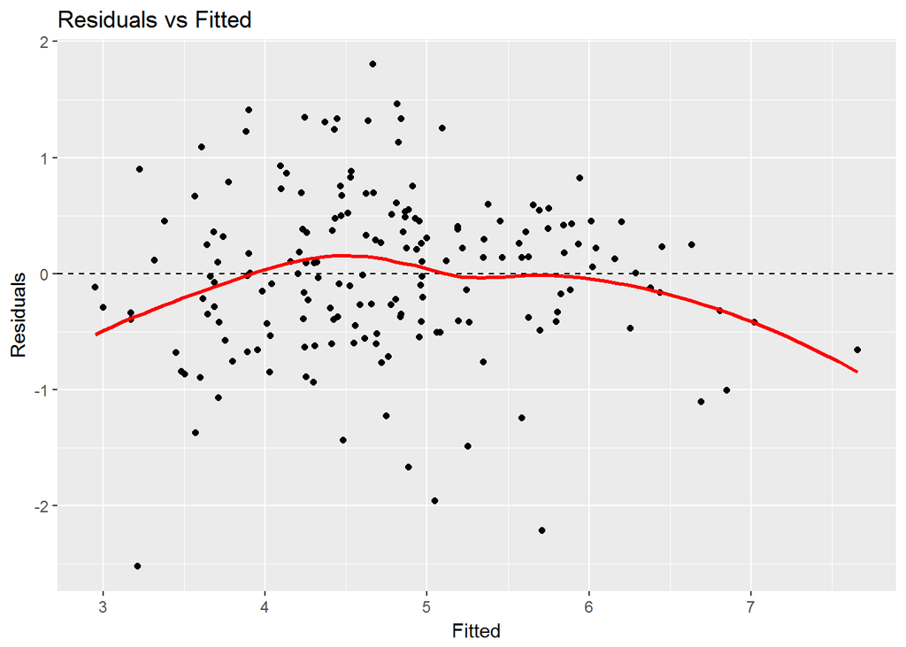

```r
mod3 <- fortify(g4)
p3 <- qplot(.fitted, .resid, data = mod2) + geom_hline(yintercept = 0, linetype = "dashed") +
  labs(title = "Residuals vs Fitted", x = "Fitted", y = "Residuals") + geom_smooth(color = "red",  se = F)
p3
```

```r
g5 <- step(g4)
```

```
## Start:  AIC=-126.43
## subs ~ citeprice + I(citeprice^2) + I(citeprice^3) + age + I(age *
##     citeprice) + chars
##
##                      Df Sum of Sq    RSS     AIC
## - I(citeprice^3)      1    0.1362 82.636 -128.13
## - I(citeprice^2)      1    0.2232 82.723 -127.94
## <none>                            82.500 -126.43
## - chars               1    2.3304 84.830 -123.42
## - I(age * citeprice)  1    3.8186 86.318 -120.28
## - age                 1    8.3110 90.811 -111.15
## - citeprice           1   12.2988 94.798 -103.42
##
## Step:  AIC=-128.13
## subs ~ citeprice + I(citeprice^2) + age + I(age * citeprice) +
##     chars
##
##                      Df Sum of Sq    RSS     AIC
## - I(citeprice^2)      1    0.1017 82.738 -129.91
## <none>                            82.636 -128.13
## - chars               1    2.2406 84.876 -125.32
## - I(age * citeprice)  1    3.8094 86.445 -122.02
## - age                 1    8.3266 90.962 -112.85
## - citeprice           1   12.2911 94.927 -105.17
##
## Step:  AIC=-129.91
## subs ~ citeprice + age + I(age * citeprice) + chars
##
##                      Df Sum of Sq    RSS     AIC
## <none>                            82.738 -129.91
## - chars               1    2.2526 84.990 -127.08
## - I(age * citeprice)  1    4.6733 87.411 -122.02
## - age                 1    8.3321 91.070 -114.64
## - citeprice           1   14.6456 97.383 -102.58
```

**Comparing both the models**

```r
anova(g5,g4)
```

```
## Analysis of Variance Table
##
## Model 1: subs ~ citeprice + age + I(age * citeprice) + chars
## Model 2: subs ~ citeprice + I(citeprice^2) + I(citeprice^3) + age + I(age *
##     citeprice) + chars
##   Res.Df    RSS Df Sum of Sq      F Pr(>F)
## 1    175 82.738
## 2    173 82.500  2    0.2379 0.2494 0.7795
```

Analysis: We take the first model Since the F-ratio is small

Performing Cross Validation on our two models

```r
library(DAAG)
seed <- round(runif(1, min=0, max=100))
oldpar <- par(mfrow=c(2,3))
mse.g2 <- CVlm(data = journals,
               form.lm=g3,
               m=4,
               seed=seed,
               printit=F,
               main = "g3") #g3 is our model lm(subs^lam ~ citeprice + age + I(age * citeprice) +chars, data = log(journals))
mse.g3 <- CVlm(data = journals,
               form.lm=g4,
               m=4,
               seed=seed,
               printit=F,
               main = "g4") #g4 is this model lm(subs ~ citeprice + I(citeprice^2) + I(citeprice^3) +age + I(age * #citeprice) + chars, data = log(journals))
data.frame(
           mse.g2=attr(mse.g2, "ms"),
           mse.g3=attr(mse.g3, "ms"))
```

```
##     mse.g2   mse.g3
## 1 32566.07 275992.6
```

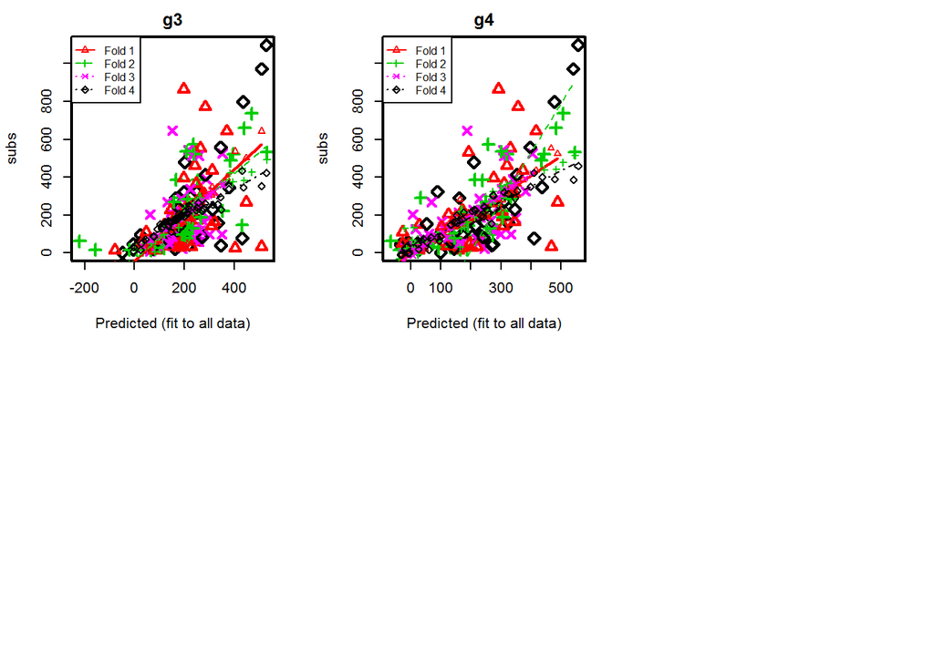

**BOX Cox Transform**

```r
 library(car)
  (lambda <- powerTransform(g4))
```

```
## Estimated transformation parameters
##       Y1
## 1.604823
```

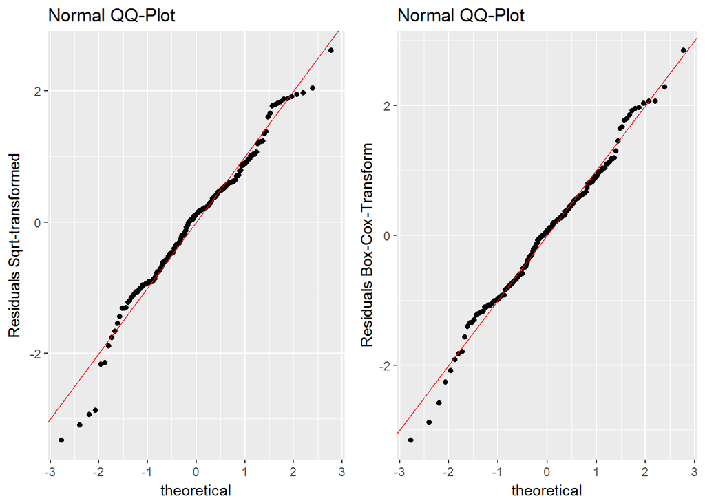

```r
  lam <- lambda$lambda
  glam <- lm(subs^lam ~ citeprice + age + I(age * citeprice) + chars, data = log(journals))
  modlam <- fortify(glam)
  p1 <- qplot(sample = scale(.resid), data = mod3) + geom_abline(intercept = 0,
                                                                  slope = 1, color = "red") + labs(title = "Normal QQ-Plot", y = "Residuals Sqrt-transformed")
  p2 <- qplot(sample = scale(.resid), data = modlam) + geom_abline(intercept = 0,
                                                                   slope = 1, color = "red") + labs(title = "Normal QQ-Plot", y = "Residuals Box-Cox-Transform")
  grid.arrange(p1, p2, nrow = 1)
```

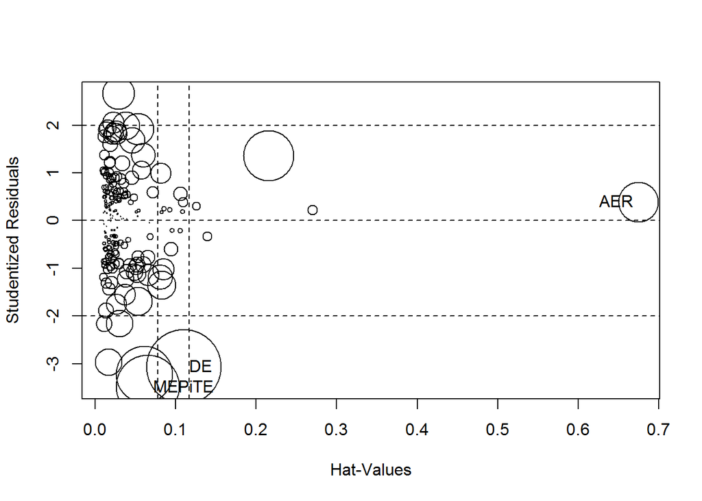

```
##           StudRes        Hat      CookD
## MEPiTE -3.4874036 0.06564693 0.11467160
## DE     -3.0645984 0.11022511 0.15851781
## AER     0.3907418 0.67467807 0.04545664
```

```r
influencePlot(g4)
```

# We can Clearly see outliers using Cooks distance

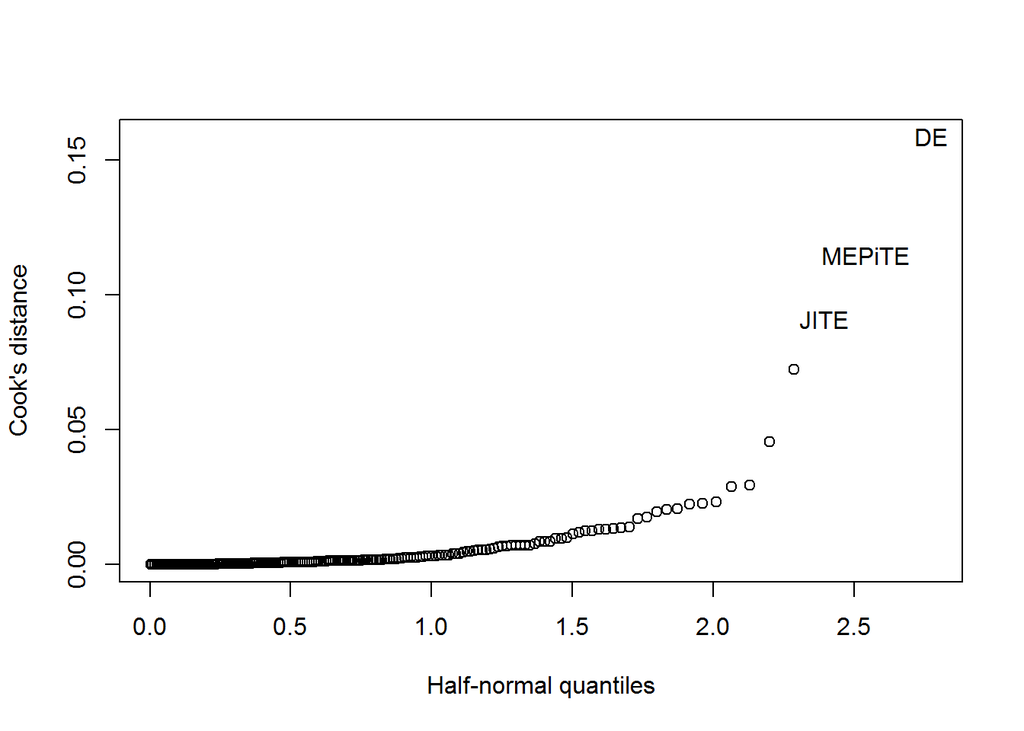

```r
journ <- row.names(journals)
cook <- cooks.distance(g4)
halfnorm(cook, 3, labs = journ, ylab = "Cook's distance")
```

**Creating of Test and Training data**

```r
train=sample(1:dim(journals)[1],120)
test=-train

traindata=journals[train,]
testdata=journals[-train,]
testoutput=journals$subs[-train]
head(testoutput)
```

```
## [1] 14 17 96 30 62 16
```

```r
testoutput<-ifelse(testoutput<300, 'low',"high")
```

```r
newg<-lm(subs^lam ~ citeprice + age + I(age * citeprice) + chars, data = log(traindata))
summary(newg)
```

```
##
## Call:
## lm(formula = subs^lam ~ citeprice + age + I(age * citeprice) +
##     chars, data = log(traindata))
##
## Residuals:
##     Min      1Q  Median      3Q     Max
## -7.7739 -1.8520  0.2012  1.4084  7.5728
##
## Coefficients:
##                    Estimate Std. Error t value Pr(>|t|)
## (Intercept)          7.0414     1.5093   4.665 8.39e-06 ***
## citeprice           -2.6758     0.8321  -3.216 0.001690 **
## age                  1.5627     0.4382   3.567 0.000528 ***
## I(age * citeprice)   0.2789     0.2457   1.135 0.258698
## chars                0.6377     0.4843   1.317 0.190522
## ---
## Signif. codes:  0 '***' 0.001 '**' 0.01 '*' 0.05 '.' 0.1 ' ' 1
##
## Residual standard error: 2.712 on 115 degrees of freedom
## Multiple R-squared:  0.6299, Adjusted R-squared:  0.617
## F-statistic: 48.93 on 4 and 115 DF,  p-value: < 2.2e-16
```

```r
confint(newg)
```

```
##                         2.5 %     97.5 %
## (Intercept)         4.0517461 10.0311079
## citeprice          -4.3240486 -1.0275036
## age                 0.6948392  2.4306263
## I(age * citeprice) -0.2077760  0.7655128
## chars              -0.3215666  1.5969898
```

**Improvement of our Model**

Initially we started our model with R2 of **0.544** by improving our models and getting rid other variables and using quadratic function of the variables The new R2 is **0.60**

```r
testing<-ifelse(testdata$subs<300,'low','high')
testdata=data.frame(testdata,testing)
test<-ifelse(testdata$subs<300,'low','high')
testdata=data.frame(testdata,testing)

q<-predict(newg,testdata,interval = 'predict')
q<-ifelse(q<300,'low',"high")
mean((q==testoutput))
```

```
## [1] 0.7166667
```

**ANALYSIS of our result**